# Discriminant Analyis, ROC Curves and Beyond Binary

Rafael Irizarry

### Topics

- Review of our two features example
- Linear and Quadratic Discriminant Analysis
- ROC curves
- Three categories

### Digit Reader Example Continued

Read-in the data:

```r
url <- "https://raw.githubusercontent.com/datasciencelabs/data/master/hand-written-digits-train.csv"
digits <- read_csv(url)
```

Consider only 2s and 7s:

```r
dat <- digits %>% filter(label%in%c(2,7))
```

### Two features

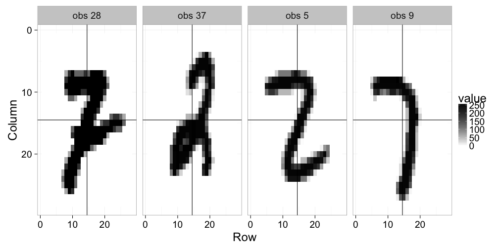

### Two predictors

```r
row_column <- expand.grid(row=1:28, col=1:28)
ind1 <- which(row_column$col <= 14 &
                row_column$row <=14)
ind2 <- which(row_column$col > 14 &
                row_column$row > 14)
X <- as.matrix(dat[,-1])
X <- X>200
X1 <- rowSums(X[,ind1])/rowSums(X)
X2 <- rowSums(X[,ind2])/rowSums(X)
dat <- mutate(dat, X_1 = X1, X_2 = X2)
```

### Example

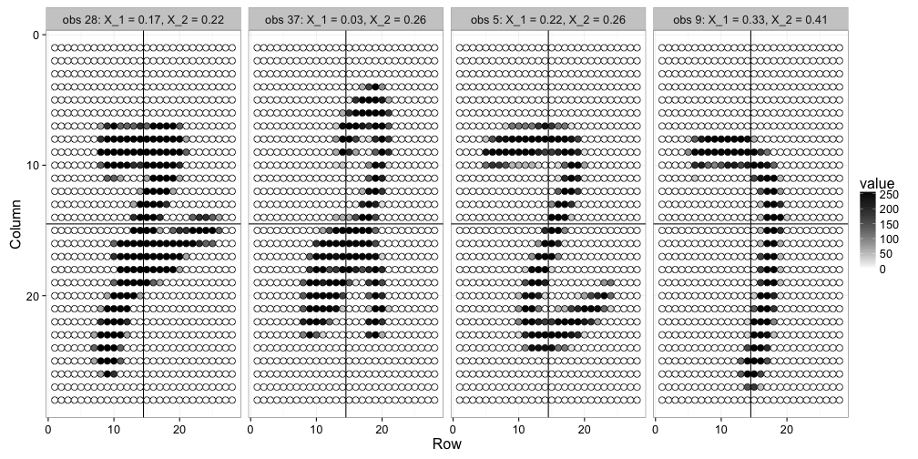

### The True Conditional Probabilities

This is an example, in practice we don't have this:

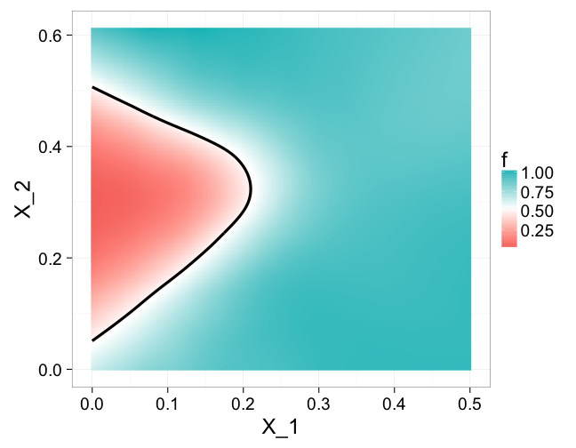

### Discriminant Analysis

Take a subset and create train and test set:

```r
library(caret)
dat <- sample_n(dat, 1000) %>%
  select(y, X_1, X_2)
inTrain <- createDataPartition(
  y = dat$y,
  p = 0.5)$Resample1
train_set <- slice(dat, inTrain)
test_set <- slice(dat, -inTrain)
```

### QDA

Quadratic Discriminant Analysis (QDA) relates to the *Naive Bayes*

We try to estimate \( \mbox{Pr}(Y=1|X=x) \) using Bayes theorem.

\[ f(x) = \mbox{Pr}(Y=1|\mathbf{X}=\mathbf{x}) = \frac{\pi p_{\mathbf{X}|Y=1}(\mathbf{x})} {(1-\pi) p_{\mathbf{X}|Y=0}(x) + \pi p_{\mathbf{X}|Y=1}(x)} \] Assume \( p \) is normal

### Fit the model

We need averages, SDs and correlations:

```r
params <- train_set %>% group_by(y) %>%
  summarize(
    avg_1 = mean(X_1),avg_2 = mean(X_2),
    sd_1= sd(X_1), sd_2 = sd(X_2),
    r = cor(X_1,X_2))
```

```
Source: local data frame [2 x 6]

      y avg_1 avg_2  sd_1  sd_2     r
  (dbl) (dbl) (dbl) (dbl) (dbl) (dbl)
1     0  0.13  0.29 0.064 0.062  0.41
2     1  0.24  0.29 0.076 0.100  0.50
```

### Data and Fitted Model

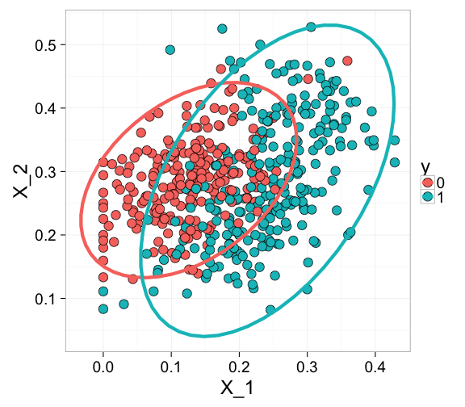

### The Classification Rule

Estimate of \( \,f(x_1, x_2) \) compared to true \( \,f \)

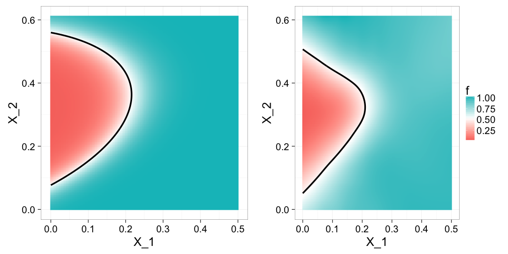

### Problem in Higher Dimensions

With 10 we have 45 correlations for each class.

\( p(p-1)/2 \) which gets big fast.

### Linear Discriminant Analysis

Assume correlations and SDs are same across classes:

```r
params <-params %>% mutate(sd_1 = mean(sd_1),
                           sd_2=mean(sd_1),
                           r=mean(r))
params
```

```
Source: local data frame [2 x 6]

      y avg_1 avg_2  sd_1  sd_2     r
  (dbl) (dbl) (dbl) (dbl) (dbl) (dbl)
1     0  0.13  0.29  0.07  0.07  0.45
2     1  0.24  0.29  0.07  0.07  0.45
```

### LDA Estimate

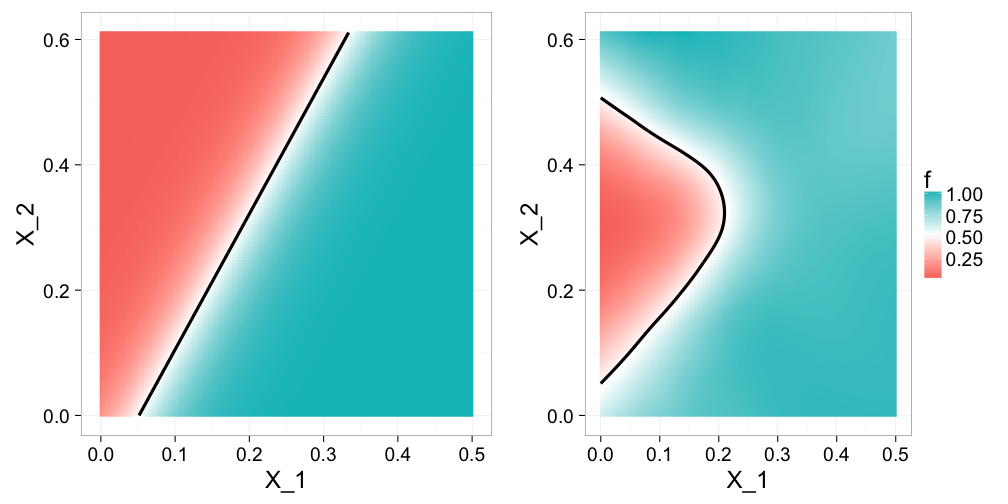

### Connection distance

\[ p(x) = \frac{1}{\sqrt{2\pi} \sigma} \exp\left\{ - \frac{(x-\mu)^2}{\sigma^2}\right\} \]

Take out constant and take log:

\[ - \frac{(x-\mu)^2}{\sigma^2} \]

### Receiver Operating Characteristic Curves

We have been calling 7s if \( \,\hat{f}(x_1,x_2)>0.5 \).

This cut-off assumes both errors are the same but we have continuum

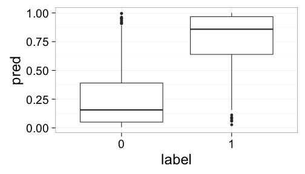

### ROC Curves

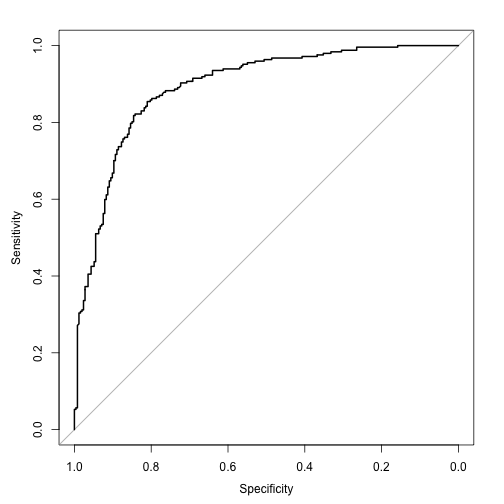

```
Call:
roc.default(response = test_set$y, predictor = pred_qda)

Data: pred_qda in 253 controls (test_set$y 0) < 247 cases (test_set$y 1).
Area under the curve: 0.89
```

```r
library(pROC)
roc_qda <- roc(test_set$y, pred_qda)
plot(roc_qda)
```

### LDA

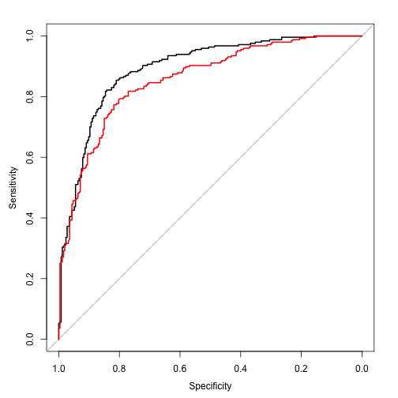

### kNN 5 and 51

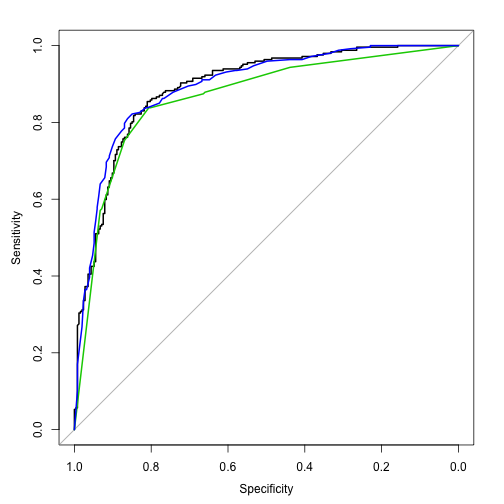

### Three classes

```r
dat <- digits %>% filter(label%in%c(1,2,7))
```

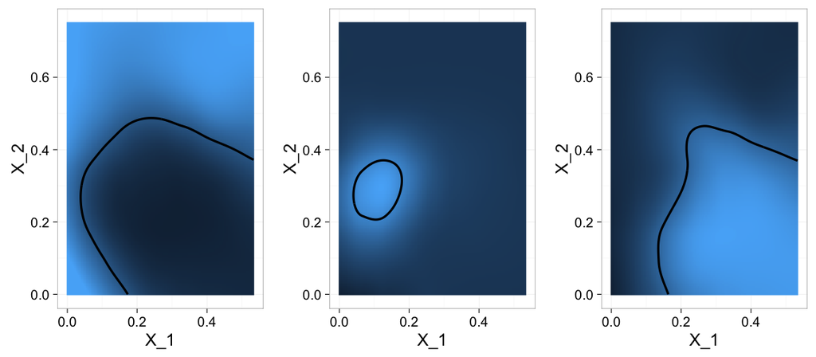

### The Data

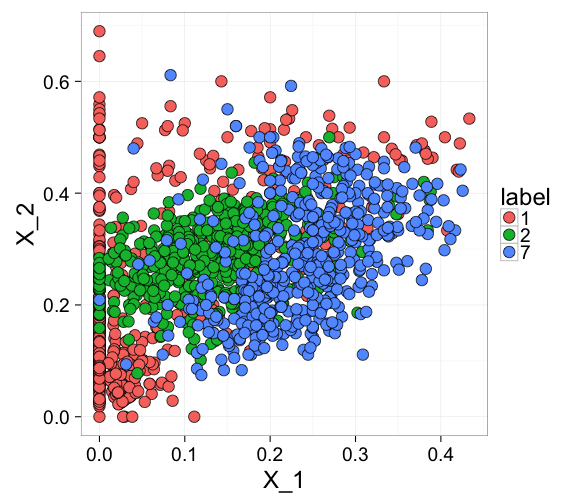

### LDA

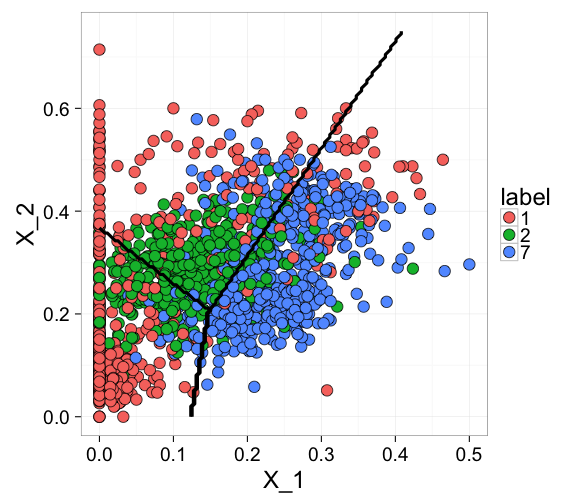

### QDA

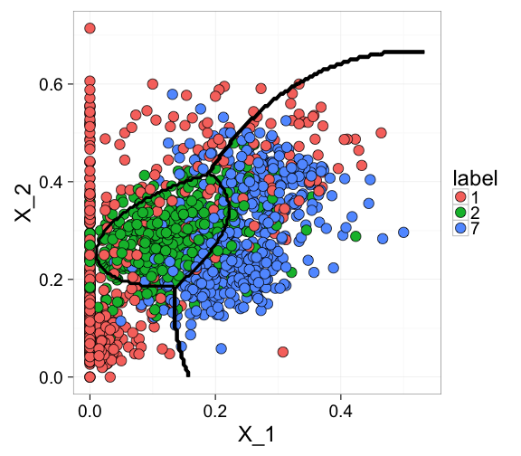

### GLM

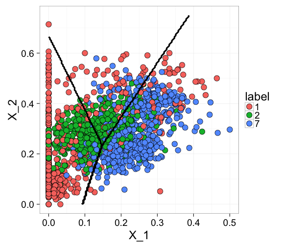

### kNN 101

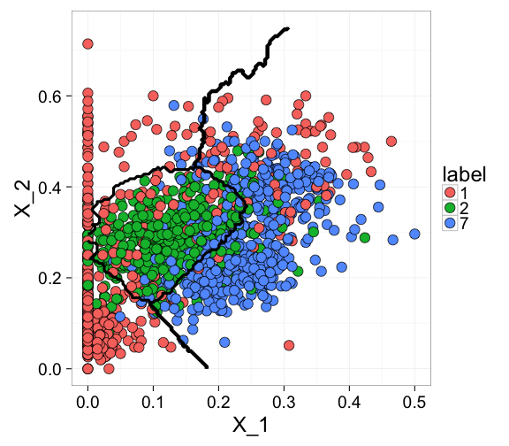

### kNN 51

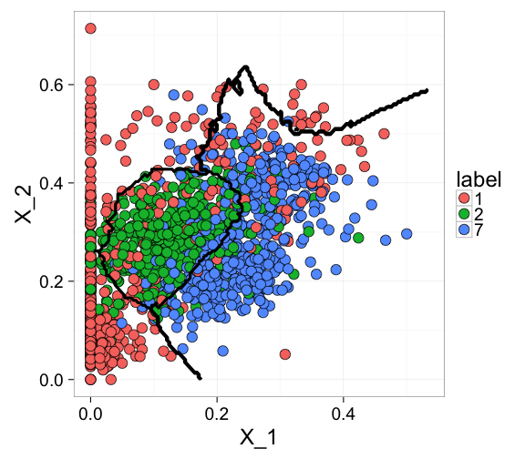

### Comparison

Let's compare:

```r
tab <- table(factor(pred_lda, labels=c("1","2","7")), test_set$label)
confusionMatrix(tab)
confusionMatrix(tab)$overall[1]
```

### Results

```
Confusion Matrix and Statistics


      1   2   7
  1 344 128  25
  2 131 261  80
  7  57  86 388

Overall Statistics

               Accuracy : 0.662
                 95% CI : (0.637, 0.686)
    No Information Rate : 0.355
    P-Value [Acc > NIR] : < 2e-16

                  Kappa : 0.493
 Mcnemar's Test P-Value : 0.00524

Statistics by Class:

                     Class: 1 Class: 2 Class: 7
Sensitivity             0.647    0.549    0.787
Specificity             0.842    0.794    0.858
Pos Pred Value          0.692    0.553    0.731
Neg Pred Value          0.813    0.792    0.892
Prevalence              0.355    0.317    0.329
Detection Rate          0.229    0.174    0.259
Detection Prevalence    0.331    0.315    0.354
Balanced Accuracy       0.744    0.672    0.823
```

```
Accuracy
    0.66
```

### Results

```
Accuracy
    0.76
```

```
Accuracy
    0.63
```

```
Accuracy
    0.77
```

```
Accuracy
    0.76
```